# Regression Analysis for industrial melter system

Pok Hei Tang (CIS: cbnn16)

# General Instructions

Please go through the R notebook below, and carry out the requested tasks. You will provide all your answers directly into this .Rmd file. Add code into the R chunks where requested. You can create new chunks where required. Where text answers are requested, please add them directly into this document, typically below the R chunks, using R Markdown syntax as adequate.

At the end, you will submit both your worked .Rmd file, and a `knitted’ PDF version, through DUO.

**Important**: Please ensure carefully whether all chunks compile, and also check in the knitted PDF whether all R chunks did *actually* compile, and all images that you would like to produce have *actually* been generated. **An R chunk which does not compile will give zero marks, and a picture which does not exist will give zero marks, even if some parts of the required code are correct.**

**Note**: It is appreciated that some of the requested analyses requires running R code which is not deterministic. So, you will not have full control over the output that is finally generated in the knitted document. This is fine. It is clear that the methods under investigation carry uncertainty, which is actually part of the problem tackled in this assignment. Your analysis should, however, be robust enough so that it stays in essence correct under repeated execution of your data analysis.

# Reading in data

We consider data from an industrial melter system. The melter is part of a disposal procedure, where a powder (waste material) is clad in glass. The melter vessel is continuously filled with powder, and raw glass is discretely introduced in the form of glass frit. This binary composition is heated by induction coils, positioned around the melter vessel. Resulting from this heating procedure, the glass becomes molten homogeneously [(Liu et al, 2008)](https://aiche.onlinelibrary.wiley.com/doi/full/10.1002/aic.11526).

Measurements of 15 temperature sensors `temp1`, …, `temp15` (in $^{\circ} C$), the power in four induction coils `ind1`,…, `ind4`, the `voltage`, and the `viscosity` of the molten glass, were taken every 5 minutes. The sample size available for our analysis is $n=900$.

We use the following R chunk to read the data in

```r
melter<-read.table("http://maths.dur.ac.uk/~dma0je/Data/melter.dat", header=TRUE)
```

If this has gone right, then the following code

```r
is.data.frame(melter)
```

```
[1] TRUE
```

```r
dim(melter)
```

```
[1] 900  21
```

should tell you that `melter` is a data frame of dimension $900 \times 21$. Otherwise something has gone wrong, and you need to start again.

To get more familiar with the data frame, please also execute

```r
head(melter)
```

|  | viscosity | voltage | ind1 | ind2 | ind3 | ind4 | temp1 | temp2 | temp3 | temp4 | temp5 | temp6 | temp7 | temp8 | temp9 | temp10 | temp11 | temp12 | temp13 | temp14 | temp15 |
| --- | --- | --- | --- | --- | --- | --- | --- | --- | --- | --- | --- | --- | --- | --- | --- | --- | --- | --- | --- | --- | --- |
| 1 | 531 | 354.6 | 19.71 | 19.31 | 10.4800 | 15.68 | 1052 | 1087 | 1112 | 1124 | 1055 | 1156 | 1063 | 1103 | 1017 | 1020 | 997.1 | 1044 | 847.9 | 1092 | 1092 |
| 2 | 0 | 364.7 | 21.13 | 21.17 | 8.5130 | 12.47 | 1052 | 1123 | 1151 | 1075 | 1128 | 1164 | 1079 | 1139 | 1068 | 1069 | 1062.0 | 1113 | 826.3 | 1149 | 1118 |
| 3 | 1020 | 385.8 | 19.79 | 24.15 | 0.5128 | 13.88 | 1047 | 1124 | 1152 | 1078 | 1120 | 1169 | 1072 | 1137 | 1067 | 1076 | 1072.0 | 1108 | 833.7 | 1149 | 1118 |
| 4 | 678 | 357.7 | 22.37 | 20.32 | 8.1610 | 13.54 | 1054 | 1116 | 1158 | 1066 | 1131 | 1151 | 1080 | 1147 | 1071 | 1062 | 1057.0 | 1110 | 824.4 | 1151 | 1121 |
| 5 | 753 | 379.8 | 19.28 | 23.91 | 7.6780 | 12.85 | 1054 | 1132 | 1157 | 1069 | 1144 | 1161 | 1109 | 1153 | 1081 | 1070 | 1069.0 | 1153 | 873.3 | 1163 | 1136 |
| 6 | 835 | 389.0 | 23.91 | 25.20 | 5.7580 | 15.09 | 1058 | 1140 | 1156 | 1074 | 1148 | 1158 | 1135 | 1145 | 1082 | 1077 | 1083.0 | 1138 | 895.6 | 1159 | 1130 |

```r
colnames(melter)
```

```
 [1] "viscosity" "voltage"   "ind1"      "ind2"      "ind3"
 [6] "ind4"      "temp1"     "temp2"     "temp3"     "temp4"
[11] "temp5"     "temp6"     "temp7"     "temp8"     "temp9"
[16] "temp10"    "temp11"    "temp12"    "temp13"    "temp14"
[21] "temp15"
```

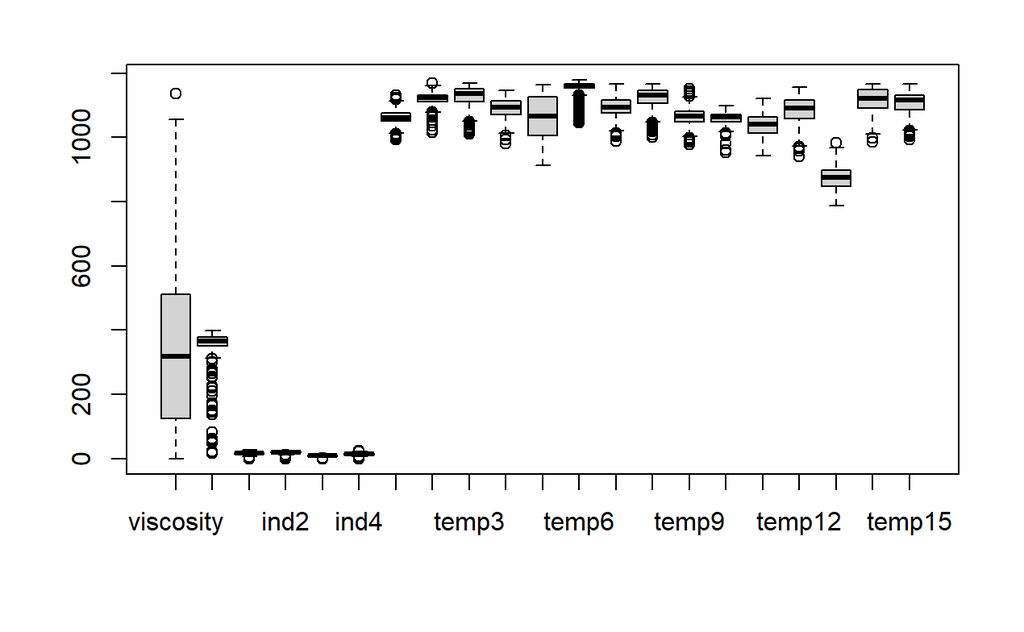

```r
boxplot(melter)
```

# Task 1: Principal component analysis (10 marks)

We consider initially only the 15 variables representing the temperature sensors. Please create a new data frame, called `Temp`, which contains only these 15 variables. Then carry out a principal component analysis. (Use your judgement on whether, for this purpose, the temperature variables require scaling or not). Produce a screeplot, and also answer the following questions: How many principal components are needed to capture 90% of the total variation? How many are needed to capture 98%?

**Answer:**

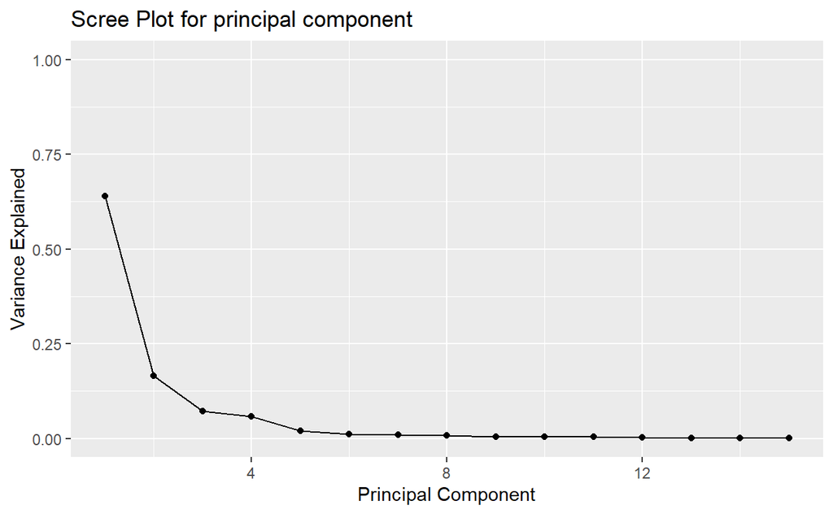

```r
# ---
Temp <- melter[, 7:21]


# Since the temperature detected by the sensors have same unit and similar ranges, it does not need to be scaled

Temp.pr <- prcomp(Temp)

var_exp = Temp.pr$sdev^2 / sum(Temp.pr$sdev^2)

library(ggplot2)



qplot(c(1:15), var_exp) +
  xlab("Principal Component") +
  ylab("Variance Explained") +
  ggtitle("Scree Plot for principal component") +
  geom_line() +

  ylim(0, 1)
```

```r
summary(Temp.pr)
```

```
Importance of components:
                            PC1     PC2      PC3      PC4      PC5
Standard deviation     104.1530 53.0084 34.71517 31.46307 18.06295
Proportion of Variance   0.6401  0.1658  0.07111  0.05841  0.01925
Cumulative Proportion    0.6401  0.8059  0.87705  0.93546  0.95471
                            PC6      PC7      PC8     PC9    PC10    PC11
Standard deviation     13.44122 12.56748 11.29045 8.78997 8.47036 7.78263
Proportion of Variance  0.01066  0.00932  0.00752 0.00456 0.00423 0.00357
Cumulative Proportion   0.96537  0.97469  0.98222 0.98678 0.99101 0.99458
                          PC12    PC13    PC14    PC15
Standard deviation     6.88028 4.58557 3.72835 3.08682
Proportion of Variance 0.00279 0.00124 0.00082 0.00056
Cumulative Proportion  0.99738 0.99862 0.99944 1.00000
```

```r
pr = 1
p90 = 0
while (p90 < 0.9){
  p90 = p90 + (Temp.pr$sdev^2)[pr] /sum(Temp.pr$sdev^2)
  pr = pr + 1
}


print(paste("The principal components needed for 90% is ", pr-1))
```

```
[1] "The principal components needed for 90% is  4"
```

```r
pr = 1
p98 = 0
while (p98 <= 0.98){
  p98 = p98 + (Temp.pr$sdev^2)[pr] /sum(Temp.pr$sdev^2)
  pr = pr + 1
}


print(paste("The principal components needed for 98% is ", pr-1))
```

```
[1] "The principal components needed for 98% is  8"
```

It needs 4 principal components to capture 90% of total variations. It needs 8 principal components to capture 98% of total variations.

# Task 2: Multiple linear regression (20 marks)

We consider from now on, and for the remainder of this assignment, `viscosity` as the response variable.

Fit a linear regression model, with `viscosity` as response variable, and all other variables as predictors, and produce the `summary` output of the fitted model. In this task, we are mainly interested in the standard errors of the estimated coefficients. Create a vector, with name `melter.fit.sd`, which contains the standard errors of all estimated coefficients, except the intercept. (So, this vector should have length 20). Then produce a `barplot` of these standard errors (where the height of each bar indicates the value of the standard error of the respective coefficients). Please use blue color to fill the bars of the barplot.

**Answer:**

```r
#---

melter.fit <- lm(viscosity~., data=melter)
summary(melter.fit)
```

```
Call:
lm(formula = viscosity ~ ., data = melter)

Residuals:
    Min      1Q  Median      3Q     Max
-528.65 -104.72    8.94  113.19  998.39

Coefficients:
            Estimate Std. Error t value Pr(>|t|)
(Intercept) 233.0410   773.4186   0.301  0.76325
voltage       0.2861     0.1187   2.410  0.01616 *
ind1         -2.0576     2.0219  -1.018  0.30911
ind2         11.5769     2.3166   4.997 7.01e-07 ***
ind3         -6.4460     4.0011  -1.611  0.10753
ind4          5.7859     2.5632   2.257  0.02424 *
temp1         3.3334     0.8122   4.104 4.44e-05 ***
temp2        -7.8144     1.1885  -6.575 8.32e-11 ***
temp3         3.3522     1.8229   1.839  0.06626 .
temp4        -1.7946     0.5294  -3.390  0.00073 ***
temp5         0.1459     0.3953   0.369  0.71220
temp6         1.5851     0.5776   2.744  0.00619 **
temp7        -0.7183     0.8423  -0.853  0.39402
temp8         6.6493     1.4509   4.583 5.25e-06 ***
temp9        -2.1935     0.6492  -3.379  0.00076 ***
temp10        0.4241     0.7184   0.590  0.55509
temp11       -0.6485     0.4190  -1.548  0.12203
temp12        0.7973     0.6999   1.139  0.25496
temp13        1.3418     0.6262   2.143  0.03240 *
temp14        1.5841     1.2645   1.253  0.21063
temp15       -6.0903     1.3275  -4.588 5.13e-06 ***
---
Signif. codes:  0 ‘***’ 0.001 ‘**’ 0.01 ‘*’ 0.05 ‘.’ 0.1 ‘ ’ 1

Residual standard error: 196 on 879 degrees of freedom
Multiple R-squared:  0.3485,    Adjusted R-squared:  0.3337
F-statistic: 23.51 on 20 and 879 DF,  p-value: < 2.2e-16
```

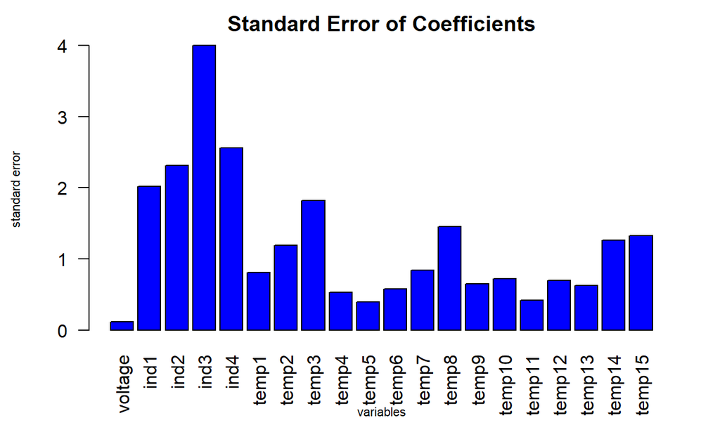

```r
melter.fit.sd <- coef(summary(melter.fit))[, "Std. Error"][2:21]

barplot(melter.fit.sd, main="Standard Error of Coefficients", col="blue", las=2, ylab="standard error", xlab = "variables", cex.lab =0.7)
```

Now repeat this analysis, but this time using a Bayesian linear regression. Use adequate methodology to fit the Bayesian version of the linear model considered above. It is your choice whether you would like to employ ready-to-use R functions which carry out this task for you, or whether you would like to implement this procedure from scratch, for instance using `jags`.

In either case, you need to be able to extract posterior draws of the estimated parameters from the fitted object, and compute their standard deviations. Please save these standard deviations, again excluding that one for the intercept, into a vector `melter.bayes.sd`. Produce now a barplot which displays both of `melter.fit.sd` and `melter.bayes.sd` in one plot, and allows a direct comparison of the frequentist and Bayesian standard errors (by having the corresponding bars for both methods directly side-by-side, with the Bayesian ones in red color). The barplot should be equipped with suitable labels and legends to enable good readability.

Comment on the outcome.

**Answer**:

```r
#---
model_string <- "model{
  for(i in 1:N){
    y[i] ~ dnorm(mu[i], tau)   # tau = precision=inverse variance
    mu[i] <- beta0+beta%*%X[i,]
  }
  # Prior distribution on mean
    beta0 ~ dnorm(0, 0.0001);
    for (j in 1:20){
      beta[j]~  dnorm(0, 0.0001)
    }
    tau  ~ dgamma(0.01, 0.01)
    sigma<- 1/sqrt(tau)

}"
```

```r
melterX = as.matrix(melter[,2:21])
visc <- melter$viscosity


para = colnames(melterX)

m <- apply(melterX, 2,mean)
S <- apply(melterX, 2, sd)


SmelterX = scale(melterX)


#check mean and sd of Smelter to ensure it is scaled
apply(SmelterX, 2, mean)
```

```
      voltage          ind1          ind2          ind3          ind4
 4.624271e-16  4.092803e-17 -9.892935e-17 -1.408132e-16 -2.111491e-16
        temp1         temp2         temp3         temp4         temp5
 1.690208e-15 -2.867786e-15 -1.191861e-15 -3.129171e-15  1.507719e-15
        temp6         temp7         temp8         temp9        temp10
 1.391130e-16 -3.682137e-15 -2.800315e-15  8.161874e-18  2.126335e-15
       temp11        temp12        temp13        temp14        temp15
 1.876025e-15 -6.746071e-16  2.661131e-16 -4.123486e-16  2.539170e-15
```

```r
apply(SmelterX, 2, sd)
```

```
voltage    ind1    ind2    ind3    ind4   temp1   temp2   temp3   temp4
      1       1       1       1       1       1       1       1       1
  temp5   temp6   temp7   temp8   temp9  temp10  temp11  temp12  temp13
      1       1       1       1       1       1       1       1       1
 temp14  temp15
      1       1
```

```r
require(rjags)
model <- jags.model(textConnection(model_string),
            data = list(X=SmelterX, y=visc,N=dim(melterX)[1])
          )
update(model, 10000)
```

[output not shown]

```r
postmod.samples = coda.samples(model, c("beta0", "beta", "sigma"), 10000)[[1]]
```

[output not shown]

```r
summary(postmod.samples)
```

```
Iterations = 10001:20000
Thinning interval = 1
Number of chains = 1
Sample size per chain = 10000

1. Empirical mean and standard deviation for each variable,
   plus standard error of the mean:

             Mean     SD Naive SE Time-series SE
beta[1]    16.931  7.000  0.07000        0.09463
beta[2]    -7.035  8.262  0.08262        0.16746
beta[3]    44.407  8.830  0.08830        0.18429
beta[4]   -15.287  9.807  0.09807        0.24981
beta[5]    21.103  9.906  0.09906        0.26434
beta[6]    58.725 15.735  0.15735        0.54754
beta[7]  -141.251 22.286  0.22286        1.04688
beta[8]    93.185 49.837  0.49837        5.31703
beta[9]   -43.436 13.708  0.13708        0.63860
beta[10]    3.623 23.103  0.23103        1.26498
beta[11]   34.855 12.523  0.12523        0.36485
beta[12]  -17.070 22.928  0.22928        1.11340
beta[13]  168.923 39.380  0.39380        3.51254
beta[14]  -64.978 17.696  0.17696        0.64631
beta[15]    7.827 13.347  0.13347        0.40680
beta[16]  -21.065 13.815  0.13815        0.40077
beta[17]   37.278 29.915  0.29915        1.92709
beta[18]   35.854 21.352  0.21352        0.96281
beta[19]   62.915 42.820  0.42820        3.94041
beta[20] -147.291 39.715  0.39715        3.40850
beta0     331.502  6.549  0.06549        0.06373
sigma     196.311  4.660  0.04660        0.05201

2. Quantiles for each variable:

             2.5%      25%      50%      75%   97.5%
beta[1]     3.198   12.176   16.946   21.665  30.503
beta[2]   -23.121  -12.607   -7.027   -1.454   9.233
beta[3]    27.171   38.496   44.477   50.218  61.695
beta[4]   -34.582  -21.795  -15.314   -8.730   3.711
beta[5]     1.747   14.427   21.214   27.765  40.557
beta[6]    27.004   48.192   58.922   69.710  88.005
beta[7]  -185.497 -155.815 -141.394 -126.625 -97.687
beta[8]    -5.705   61.675   91.405  125.054 193.936
beta[9]   -70.102  -52.687  -43.605  -34.216 -16.261
beta[10]  -40.900  -12.404    3.106   19.102  49.029
beta[11]   10.509   26.515   34.855   43.294  59.296
beta[12]  -62.419  -32.236  -16.866   -1.980  28.227
beta[13]   93.905  140.802  168.398  196.773 245.678
beta[14]  -99.554  -77.082  -65.154  -52.805 -30.212
beta[15]  -18.774   -1.082    8.157   16.901  33.908
beta[16]  -47.853  -30.296  -21.180  -11.669   5.964
beta[17]  -22.349   17.138   36.931   57.329  96.139
beta[18]   -6.181   21.153   36.023   50.589  76.628
beta[19]  -23.536   32.807   65.654   92.893 141.020
beta[20] -227.638 -172.436 -146.195 -120.415 -70.615
beta0     318.686  327.116  331.537  335.872 344.502
sigma     187.533  193.190  196.225  199.375 205.708
```

```r
# check the values of the coefficients
beta.jags<- rowMeans(t(postmod.samples[,1:20])/S)
rbind(beta.jags,
      melter.fit$coef[2:21])
```

```
            beta[1]   beta[2]  beta[3]   beta[4]  beta[5]  beta[6]
beta.jags 0.2864769 -1.700155 11.32849 -6.032585 5.320628 2.919221
          0.2861037 -2.057622 11.57694 -6.446006 5.785851 3.333406
            beta[7]  beta[8]   beta[9]   beta[10] beta[11]   beta[12]
beta.jags -7.024828 2.878637 -1.595353 0.05751658 1.539372 -0.6069848
          -7.814432 3.352163 -1.794553 0.14586488 1.585094 -0.7182936
          beta[13]  beta[14]  beta[15]   beta[16]  beta[17] beta[18]
beta.jags 5.191591 -2.285920 0.4109551 -0.6276548 0.8507094 1.038125
          6.649282 -2.193514 0.4241296 -0.6485103 0.7972900 1.341832
          beta[19]  beta[20]
beta.jags 1.625265 -4.420985
          1.584132 -6.090261
```

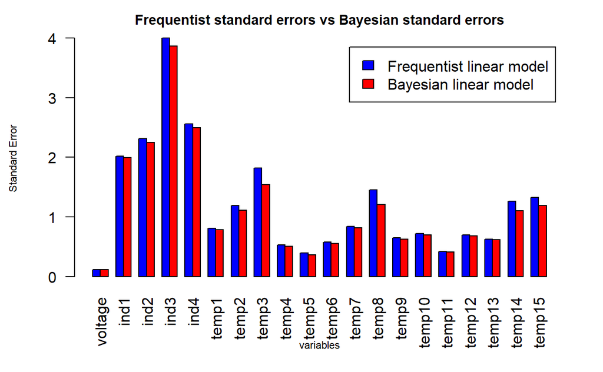

```r
# Calculate the standard error of coefficient
melter.bayes.sd <- round(apply(t(postmod.samples[,1:20])/S, 1,sd), digits=4)


# plot the bar plot with 2 methods
barplot(rbind(melter.fit.sd,
             melter.bayes.sd),
        beside=TRUE, col=c("blue", "red"),
        legend.text=c("Frequentist linear model","Bayesian linear model"), las=2,
        main = "Frequentist standard errors vs Bayesian standard errors",
        xlab = "variables", ylab = "Standard Error", cex.main = 0.9, cex.lab=0.7)
```

```r
NA
NA
NA
NA
```

The Bayesian method calculates the posterior of the coefficients $(\beta)$ from $p(\beta|X, y, \sigma^2)$ which depends on $\sigma^2$. $X$ is the predictor variables, $y$ is the response variable and $\sigma^2$ is a variable that affect the mean and variance of the posterior distribution of $\beta$. Since $\sigma^2$ is unknown, the posterior of $\sigma^2$ is calculated by some assumption of the prior of $\sigma^2$.

The frequentist method estimates the coefficient $\hat\beta$ with ordinary least square where $\hat\beta =(X^TX)^{-1}X^Ty$. $X$ is the matrix with predictor variables, $y$ is the response variable.

Standard error measures how precise the coefficient can achieve. Lower the standard error means less variation of the variables. It is observed from the barplot that nearly all of the bayesian standard error is less than the frequentist standard error. The variation of the coefficient from bayesian method is less than frequentist method.

# Task 3: The Lasso (20 marks)

We would like to reduce the dimension of the currently 20-dimensional space of predictors. We employ the LASSO to carry out this task. Carry out this analysis, which should feature the following elements:

- the trace plot of the fitted coefficients, as a function of $\log(\lambda)$, with $\lambda$ denoting the penalty parameter;
- a graphical illustration of the cross-validation to find $\lambda$;
- the chosen value of $\lambda$ according to the `1-se` criterion, and a brief explanation of what this criterion actually does;
- the fitted coefficients according to this choice of $\lambda$.

**Answer:**

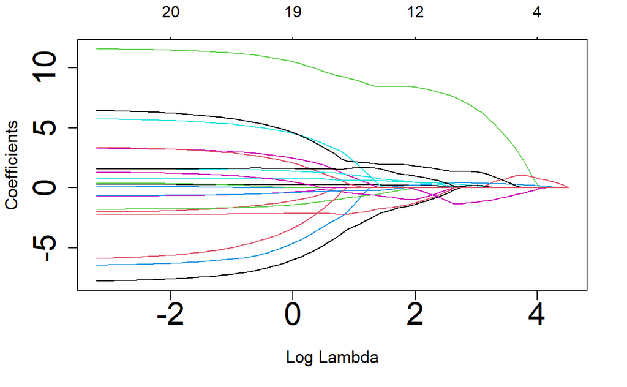

```r
#---
require(glmnet)
# set the random seed as 2
set.seed(2)


# fit the data with LASSO
melter.fit.temp= glmnet(melterX, visc, alpha=1)


# plot the trace plot
plot(melter.fit.temp, xvar="lambda",
cex.axis=2, cex.lab=1.1,
cex=1.1)
```

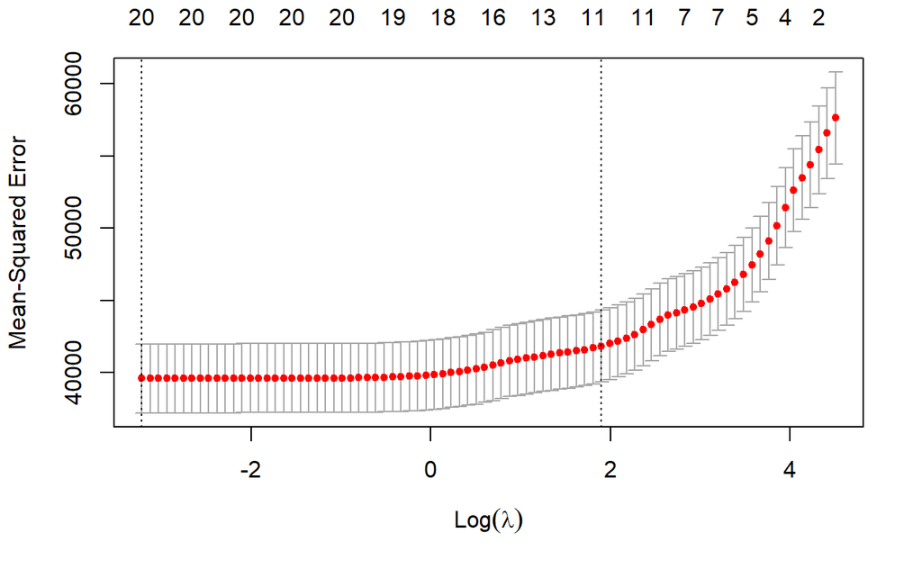

```r
# fit the data with LASSO under cross validation
melter.cv.temp = cv.glmnet(melterX,
visc, alpha=1 )


#illustration of the cross-validation
plot(melter.cv.temp)
```

```r
lambda <- melter.cv.temp$lambda.min
log(lambda)
```

```
[1] -3.216844
```

```r
lambda1 <- melter.cv.temp$lambda.1se
log(lambda1)
```

```
[1] 1.900012
```

```r
coef(melter.cv.temp, s="lambda.1se")
```

```
21 x 1 sparse Matrix of class "dgCMatrix"
                       s1
(Intercept) -339.75738342
voltage        0.21898823
ind1           .
ind2           8.45576029
ind3           .
ind4           .
temp1          .
temp2         -1.48571422
temp3          .
temp4         -0.08581453
temp5          0.21442809
temp6          0.54212892
temp7         -0.97169621
temp8          1.89268245
temp9         -1.36885750
temp10         .
temp11         .
temp12         0.47406672
temp13         .
temp14         1.08869101
temp15         .
```

`1-se` criterion finds the largest value of $\lambda$ whose cross validation value is within one standard error of the minimum mean-square error(one-standard-error rule).

The reason of using `1-se` is that the largest value of $\lambda$ whose cross validation value has the minimium mean-square error may give models which are not sparse enough.

The `1-se` criterion does not have significant increase in mean-square error but can make models more sparse.

Next, carry out a Bayesian analysis of the lasso. Visualize the full posterior distributions of all coefficients (except the intercept) in terms of boxplots, and also visualize the resulting standard errors of the coefficients, again using a barplot (with red bars).

Give an interpretation of the results, especially in terms of the evidence that this analysis gives in terms of inclusion/non-inclusion of certain variables.

**Answer:**

```r
#---
require(monomvn)
melter.blas <- blasso(melterX, visc)
```

```
t=100, m=14
t=200, m=13
t=300, m=12
t=400, m=14
t=500, m=11
t=600, m=14
t=700, m=10
t=800, m=15
t=900, m=12
```

```r
#melter.blas
summary(melter.blas)
```

```
$call
blasso(X = melterX, y = visc)

$B
[1] 0

$T
[1] 1000

$thin
[1] 20

$coef
       mu                b.1               b.2               b.3
 Min.   :-2249.58   Min.   :-0.1246   Min.   :-5.9374   Min.   : 0.000
 1st Qu.: -550.35   1st Qu.: 0.0000   1st Qu.: 0.0000   1st Qu.: 8.453
 Median : -106.91   Median : 0.2194   Median : 0.0000   Median : 9.994
 Mean   :  -81.73   Mean   : 0.2041   Mean   :-0.2432   Mean   :10.020
 3rd Qu.:  360.03   3rd Qu.: 0.3318   3rd Qu.: 0.0000   3rd Qu.:11.539
 Max.   : 2485.12   Max.   : 0.6917   Max.   : 3.9903   Max.   :18.410
      b.4                b.5              b.6             b.7
 Min.   :-12.9472   Min.   :-2.462   Min.   :0.000   Min.   :-9.048
 1st Qu.:  0.0000   1st Qu.: 0.000   1st Qu.:1.840   1st Qu.:-6.096
 Median :  0.0000   Median : 0.000   Median :2.448   Median :-5.354
 Mean   : -0.6492   Mean   : 1.784   Mean   :2.383   Mean   :-5.316
 3rd Qu.:  0.0000   3rd Qu.: 3.651   3rd Qu.:2.945   3rd Qu.:-4.573
 Max.   :  8.5728   Max.   :11.887   Max.   :4.989   Max.   : 0.000
      b.8               b.9               b.10               b.11
 Min.   :-2.0636   Min.   :-2.6559   Min.   :-0.62100   Min.   :-0.6241
 1st Qu.: 0.0000   1st Qu.:-1.3331   1st Qu.: 0.00000   1st Qu.: 0.3321
 Median : 0.3604   Median :-0.9150   Median : 0.00000   Median : 1.0732
 Mean   : 1.1341   Mean   :-0.8576   Mean   : 0.03853   Mean   : 1.0009
 3rd Qu.: 2.1595   3rd Qu.:-0.2160   3rd Qu.: 0.00000   3rd Qu.: 1.5311
 Max.   : 6.9571   Max.   : 0.4443   Max.   : 1.22859   Max.   : 3.2531
      b.12              b.13              b.14             b.15
 Min.   :-2.9874   Min.   :-0.5853   Min.   :-3.970   Min.   :-1.693241
 1st Qu.:-0.3364   1st Qu.: 3.2262   1st Qu.:-2.520   1st Qu.: 0.000000
 Median : 0.0000   Median : 4.3259   Median :-2.106   Median : 0.000000
 Mean   :-0.2617   Mean   : 4.2621   Mean   :-2.091   Mean   :-0.006265
 3rd Qu.: 0.0000   3rd Qu.: 5.3452   3rd Qu.:-1.658   3rd Qu.: 0.000000
```

[output cut: 63 more lines]

```
 Max.   :4.03747   Max.   :11.0599   Max.   :2.01082   Max.   :29.97498
 NA's   :212       NA's   :621       NA's   :102       NA's   :56

$bn0
  b.1   b.2   b.3   b.4   b.5   b.6   b.7   b.8   b.9  b.10  b.11  b.12
0.736 0.194 0.999 0.228 0.440 0.978 0.998 0.622 0.779 0.300 0.807 0.385
 b.13  b.14  b.15  b.16  b.17  b.18  b.19  b.20
0.985 0.991 0.215 0.332 0.788 0.379 0.898 0.944

$m
   Min. 1st Qu.  Median    Mean 3rd Qu.    Max.
      0      12      13      13      14      18

attr(,"class")
[1] "summary.blasso"
```

```r
# plot boxplot
plot(melter.blas, burnin=200, xlim = c(2.2, 21), ylim = c(-10, 15), las=2,
     xaxt = "n")
axis(1, at= 2:21, labels = para, las=2)
```

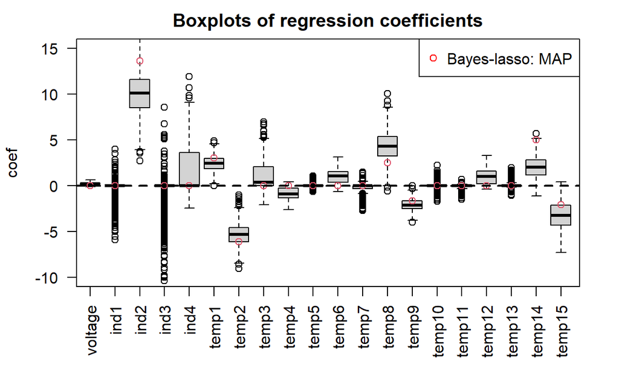

```r
legend("topright", legend = "Bayes-lasso: MAP", pch=1, col="red")
```

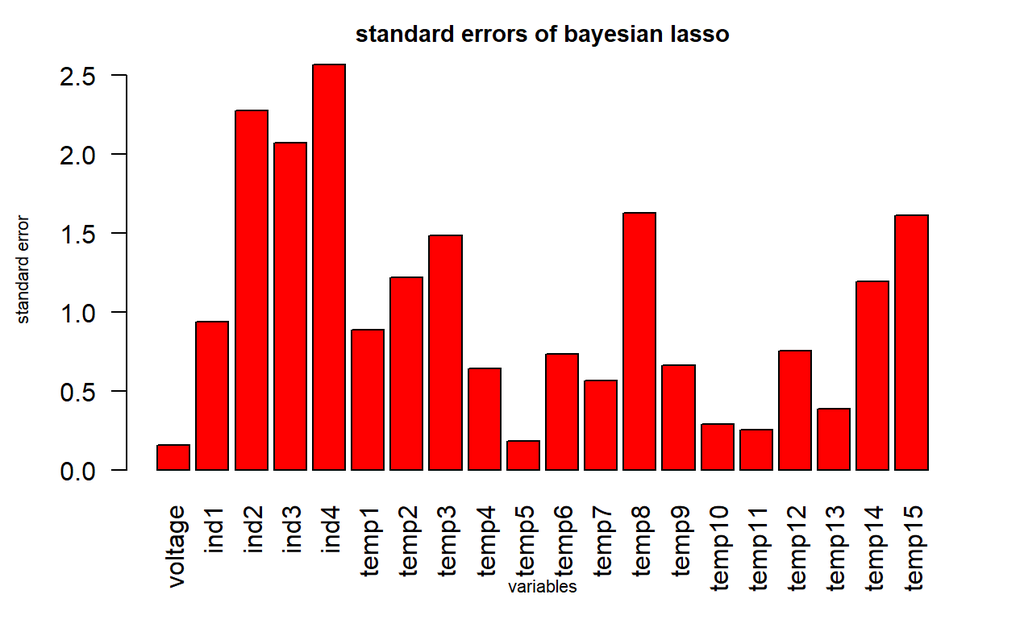

```r
# calculate the standard error
bsd <- as.matrix(apply(melter.blas$beta, 2,sd))


rownames(bsd) = para

# barplot with two methods
barplot(t(bsd), col="red", las=2
        , main= "standard errors of bayesian lasso"
        ,cex.main=0.9
        , ylab = "standard error"
        , xlab = "variables"
        , cex.lab=0.7)
```

```r
# inclusion variable -> red circle away from zero
# inclusion with certainly -> red circle away from zero and boxplot w/o intersecting with zero
```

The red circle from the boxplot is the MAP. It is the mode of the distribution. If the red circles are on the zero line, the coefficients may appear zero or near to zero under the bayesian lasso. It implies that the related coefficients can be dropped.

From the boxplot above, 8 variables have non-zero MAP. Among those MAP, “ind2” and “temp2” do not intersect with zero. Also, “temp8” and “temp9” only have the outliers intersecting with zero. Therefore, “ind2”, “temp2”, “temp8” and “temp9” are certainly included for the prediction. The coefficients needed for prediction are between 4 and 8.

On the other hand, “ind1”, “ind3”, “temp5”, “temp10” and “temp13” are certainly not-included variables because most of the samples concentrated at zero.

# Task 4: Bootstrap (20 marks)

A second possibility to assess uncertainty of any estimator is the Bootstrap. Implement a nonparametric bootstrap procedure to assess the uncertainty of your frequentist lasso fit from Task 3.

Produce boxplots of the full bootstrap distributions for all coefficients (similar as in Task 3).

Then, add (green) bars with the resulting standard errors to the bar plot produced in Task 3, allowing for comparison between Bootstrap and Bayesian standard errors. Interpret the results.

**Answer:**

```r
#---
# reset the random seed
set.seed(NULL)


# ideally 999 test
B <- 999
n <- dim(melterX)[1]
Ynew <- matrix(0, n, B)
X <- model.matrix(melter.fit)
Y<- melter$viscosity
Xnew<-list()
p<- dim(X)[2]
for (b in 1:B){
  j<-sample(n, replace=TRUE)
  Xnew[[b]]<- X[j,2:21]
  Ynew[,b]<-Y[j]
}



melter.boot<-matrix(0, B, p)

for (b in 1:B){
  melter.cv<- cv.glmnet(Xnew[[b]], Ynew[,b], alpha=1)
  melter.1se<-  coef(melter.cv , s="lambda.1se" )
  melter.boot[b,]<- as.vector(melter.1se)
  if (b%%10==0){print(b)}
}
```

```
[1] 10
[1] 20
[1] 30
[1] 40
[1] 50
[1] 60
[1] 70
[1] 80
[1] 90
[1] 100
[1] 110
[1] 120
[1] 130
[1] 140
[1] 150
```

[output cut: 84 more lines]

```r
# to find the mode
cal_mode <- function(x) {
  uni <- unique(x)
  tab <- tabulate(match(x, uni))
  uni[tab == max(tab)]
}

melter.boot.mode =apply(round(melter.boot, digit=1), 2, cal_mode)
# melter.boot.mean<- apply(melter.boot, 2, mean)

#plot the boxplot
boxplot(melter.boot[,2:21], las=2, xaxt = "n"
        , main = "boxplot of bootstrap lasso", cex.main = 0.9)
axis(1, at =1:20, label = para, las=2)
```

```r
abline(h =0, col ="black", lty = 2)
try(points(c(1:20), melter.boot.mode[2:21], col="red"), silent=TRUE)
```

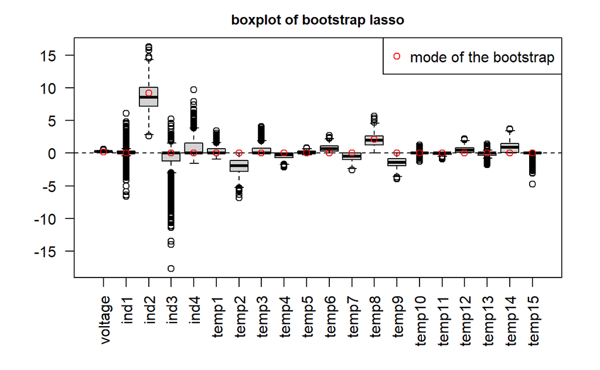

```r
legend("topright", legend = "mode of the bootstrap", pch=1, col="red")
```

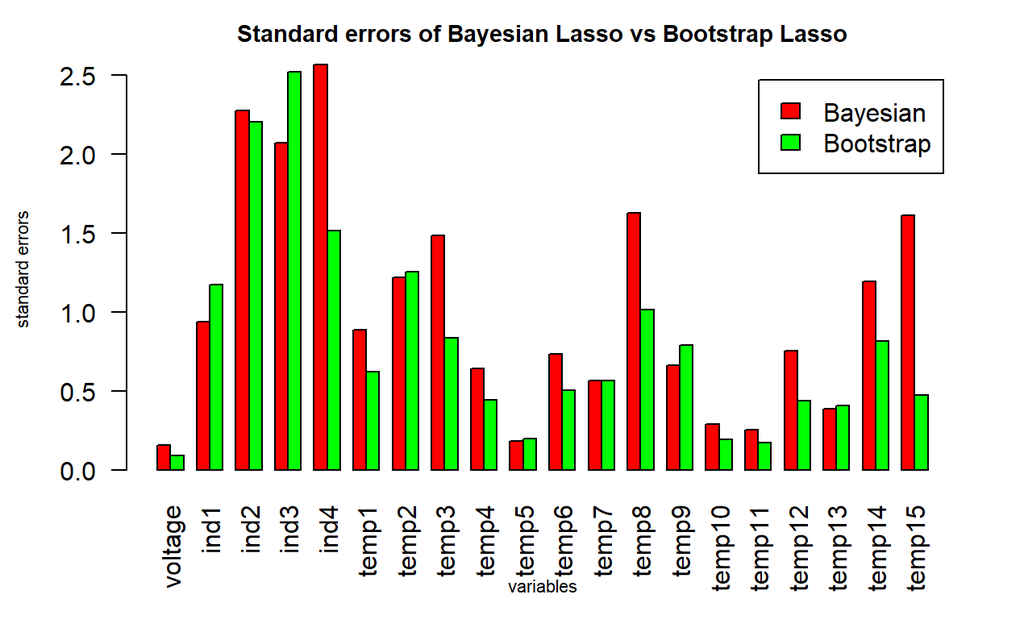

```r
# Calculate standard error and plot barplot
melter.boot.sd<- apply(melter.boot, 2, sd)

barplot(t(cbind(bsd,
          melter.boot.sd[2:21]))
        , col=c("red", "green")
        , beside=TRUE
        , legend.text=c("Bayesian","Bootstrap")
        , las=2
        , main = "Standard errors of Bayesian Lasso vs Bootstrap Lasso"
        , cex.main = 0.9
        , ylab = "standard errors"
        , xlab = "variables"
        , cex.lab=0.7)
```

```r
# count number of zeros in different coefficients in all bootstrap
counts <- list()
for (j in 2:21){
  countzero = 1
  for (i in 1:999){
    if (melter.boot[i,j] == 0){countzero = countzero + 1}
  }
  counts<-c(counts, countzero)
}

rbind(para, counts)
```

```
       [,1]      [,2]   [,3]   [,4]   [,5]   [,6]    [,7]    [,8]
para   "voltage" "ind1" "ind2" "ind3" "ind4" "temp1" "temp2" "temp3"
counts 13        570    1      640    597    566     49      606
       [,9]    [,10]   [,11]   [,12]   [,13]   [,14]   [,15]    [,16]
para   "temp4" "temp5" "temp6" "temp7" "temp8" "temp9" "temp10" "temp11"
counts 337     435     76      254     25      67      749      530
       [,17]    [,18]    [,19]    [,20]
para   "temp12" "temp13" "temp14" "temp15"
counts 209      531      212      878
```

From the boxplot above, 4 variables have non-zero mode. “ind2” is certainly included for prediction as there is no intersection with zero. “temp6” and “temp8” also have high chance to be included for prediction because they only have extreme samples hitting the zero line.

The numbers of intersection with zero are counted above. It is found that “voltage”, “temp2 and”temp9” are also a strong coefficient as the intersection time with zero is low.

# Task 5: Model choice (10 marks)

Based on all considerations and analyses carried out so far, decide on a suitable model that you would present to a client, if you had been the statistical consultant.

Formulate the model equation in mathematical notation.

Refit your selected model using ordinary Least Squares. Carry out some residual diagnostics for this fitted model, and display the results. Discuss these briefly.

**Answer:** As mentioned before, standard errors of coefficients can be used to measure the precision of the estimates. Smaller standard errors can provide more accurate result. According to above tasks, most of the variables from the bootstrap lasso method has lower standard error comparing with bayesian lasso methods. Bayesian lasso have around 5 variables which have lower standard error and only around 2 variables (“temp2” and “temp9”) play an more important role in the prediction. Therefore, it is reasonable to recommend the bootstrap lasso to the client.

Mathematical notation of bootstrap lasso:

The lasso estimator($\hat{\beta_\lambda}$): $\hat{\beta_\lambda} =argmin_\beta{||{\bf y}-{\bf X}\beta||_2^2 + \lambda ||\beta||_1}$ $= arg min_\beta\sum_{i =1}^{n}(y_i - \sum_{j=1}^{p}x_{ij}\beta_j)^2 + \lambda\sum_{j=1}^{p}|\beta_j|$

where${\bf y}$ is the vector of reponse variable, ${\bf X}$ is the matrix of predictor variables and $\lambda$ is the regularization parameter

Lasso can be solved by the ‘Karush–Kuhn–Tucker’ (KKT) conditions $\frac{1}{n}X^T(y - X \hat\beta(\lambda))=\lambda s_j$ where $s_j = sign(\hat \beta_j)$

$\hat \beta_\lambda$ can be calculated with $\hat \beta_\lambda = S_\lambda(\hat \beta^{OLS})$ where $S_\lambda(x)=sign(x)(|x|-\lambda)_+$

It is the initial lasso estimate $\hat \beta_\lambda$. New set of data is then generated by bootstrap and new lasso estimate is produced for a number of time. All the lasso estimates are stored in a matrix for further analysis

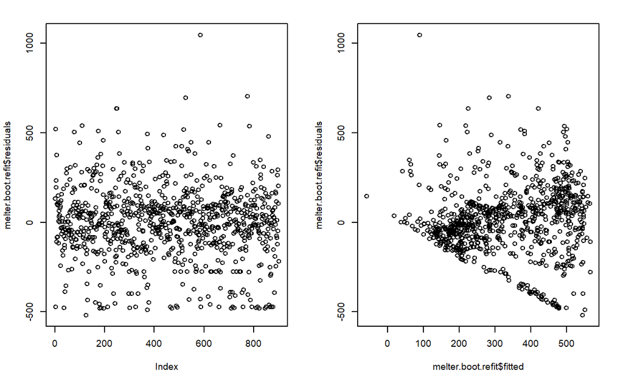

```r
#---

# Refit according to the appearance of number of zeros < 500
melter.boot.refit <- lm(viscosity~voltage + ind2 + temp2
                          + temp4 + temp5 + temp6 + temp7 + temp8
                          + temp9 + temp12 + temp14
                        , data=melter)

melter.boot.refit.sd <- coef(summary(melter.boot.refit))[, "Std. Error"][2:12]

# residual diagnostics
par(mfrow=c(1,2), cex=0.6)
plot(melter.boot.refit$residuals)
plot(melter.boot.refit$fitted, melter.boot.refit$residuals)
```

```r
summary(melter.boot.refit)
```

```
Call:
lm(formula = viscosity ~ voltage + ind2 + temp2 + temp4 + temp5 +
    temp6 + temp7 + temp8 + temp9 + temp12 + temp14, data = melter)

Residuals:
    Min      1Q  Median      3Q     Max
-518.17  -98.71    3.36  101.70 1046.28

Coefficients:
             Estimate Std. Error t value Pr(>|t|)
(Intercept) 257.05246  521.34969   0.493  0.62210
voltage       0.29457    0.12081   2.438  0.01495 *
ind2          8.24397    2.05451   4.013 6.51e-05 ***
temp2        -2.45617    0.77519  -3.168  0.00158 **
temp4        -0.85009    0.45773  -1.857  0.06362 .
temp5        -0.05065    0.29674  -0.171  0.86451
temp6         1.15319    0.56140   2.054  0.04026 *
temp7        -0.32066    0.63804  -0.503  0.61539
temp8         2.30364    0.83558   2.757  0.00595 **
temp9        -2.36402    0.58254  -4.058 5.38e-05 ***
temp12        0.72924    0.65061   1.121  0.26265
temp14        1.52673    0.83372   1.831  0.06740 .
---
Signif. codes:  0 ‘***’ 0.001 ‘**’ 0.01 ‘*’ 0.05 ‘.’ 0.1 ‘ ’ 1

Residual standard error: 201 on 888 degrees of freedom
Multiple R-squared:  0.3084,    Adjusted R-squared:  0.2998
F-statistic: 35.99 on 11 and 888 DF,  p-value: < 2.2e-16
```

```r
# melter.boot.refit$fitted.values[which(melter.boot.refit$fitted.values <0)]
```

The selection criterion of the variables for the linear model is the intersection with zero less than 500 times (provided that the bootstrap is done for 999 times).

From the plot on left hand side, it is observed that there are not any pattern from the residual. It implies that all the residual are independent.

The plot on right hand side shows the residual against predicted value, a trumpet-shape can be observed here. It implies that the homoscedasticity is violated.

We will refer to the model produced in this task as (T5) henceforth.

# Task 6: Extensions (20 marks)

For this task, take the model (T5) as the starting point. Then consider extensions of your model in TWO of the following THREE directions (of your choice).

1. Replace the temperature sensor variables in model (T5) by an adequate number of principal components (see Task 1).
2. Replace the `voltage`, and the remaining induction variables, by nonparametric terms.
3. Consider a transformation of the response variable `viscosity`.

Each time, report the fitted model through adequate means. Discuss whether the corresponding extension is useful, giving quantitative or graphical evidence where possible.

Give a short discussion on whether any of your extensions have led to an actual improvement compared to model (T5).

**Answer:**

```r
#---

#Case (1)

melter.pr <- cbind(melter, Temp.pr$x)

# refit with principal component
melter.boot.refit.1 <- lm(viscosity~ voltage + ind2
                        + PC1 + PC2 + PC3 + PC4 + PC5
                        + PC6 + PC7 + PC8
                        , data=melter.pr)

summary(melter.boot.refit.1)
```

```
Call:
lm(formula = viscosity ~ voltage + ind2 + PC1 + PC2 + PC3 + PC4 +
    PC5 + PC6 + PC7 + PC8, data = melter.pr)

Residuals:
    Min      1Q  Median      3Q     Max
-501.84  -98.13    0.35  107.39 1067.56

Coefficients:
            Estimate Std. Error t value Pr(>|t|)
(Intercept) 65.69493   55.53795   1.183 0.237171
voltage      0.31054    0.12226   2.540 0.011251 *
ind2         7.91312    2.10626   3.757 0.000183 ***
PC1          0.77057    0.06541  11.781  < 2e-16 ***
PC2          1.24819    0.13019   9.588  < 2e-16 ***
PC3          0.08450    0.20312   0.416 0.677524
PC4          1.26613    0.22125   5.723 1.43e-08 ***
PC5          0.52788    0.37773   1.398 0.162610
PC6         -1.22377    0.56654  -2.160 0.031032 *
PC7          1.35675    0.54970   2.468 0.013768 *
PC8          1.58099    0.61569   2.568 0.010396 *
---
Signif. codes:  0 ‘***’ 0.001 ‘**’ 0.01 ‘*’ 0.05 ‘.’ 0.1 ‘ ’ 1

Residual standard error: 203.8 on 889 degrees of freedom
Multiple R-squared:  0.2879,    Adjusted R-squared:  0.2799
F-statistic: 35.95 on 10 and 889 DF,  p-value: < 2.2e-16
```

```r
melter.boot.refit.sd.1 <- coef(summary(melter.boot.refit.1))[, "Std. Error"][2:11]



#comparison with barplot
par(mfrow=c(1,2))
barplot(melter.boot.refit.sd, las=2
        , main = "Standard error without extension"
        , ylab = "stnadard error"
        , xlab = "variables"
        , cex.lab = 0.7
        , cex.main=0.7)
barplot(melter.boot.refit.sd.1, las=2
        , main = "Standard error with extension (1)"
        , ylab = "stnadard error"
        , xlab = "variables"
        , cex.lab = 0.7
        , cex.main=0.7)
```

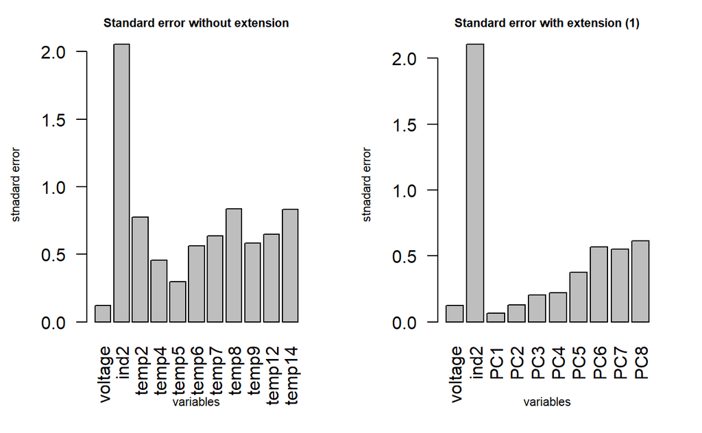

```r
#comparison with residual plot
par(mfrow=c(2,2), cex=0.4)
```

```r
plot(melter.boot.refit$residuals
     ,main = "residual plot without extension")
plot(melter.boot.refit$fitted, melter.boot.refit$residuals
     , main = "residual against fitted value without extension")
```

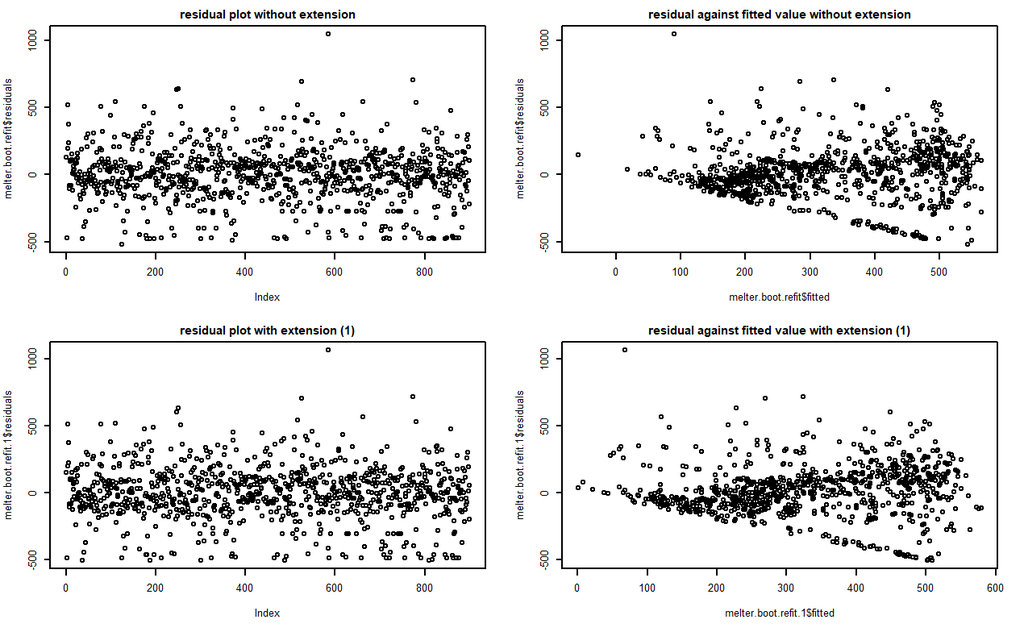

```r
plot(melter.boot.refit.1$residuals
     ,main = "residual plot with extension (1)")
plot(melter.boot.refit.1$fitted, melter.boot.refit.1$residuals
     ,main = "residual against fitted value with extension (1)")
```

```r
NA
NA
NA
NA
```

8 principal components are used here to cover 98% of total variance (from task 1) .

Comparing to Task 5, the coefficient of determination($R^2$) drops from 0.3 to 0.28 for the extension 1 which means curve is less well-fitted using the principal component of the temperature measured by the sensors.

It is observed from the barplot above that the standard error of the principal component decreases significantly for extension 1 comparing with the original temperature from the sensors.

From the residual plot above, it is found that the residuals are still independent but the homoscedasticity is still violated. The trumpet-shape does not change much.

Therefore, using principal components can reduce the standard errors with little change in coefficient of determination($R^2$). It cannot deal with the violation of homoscedasticity.

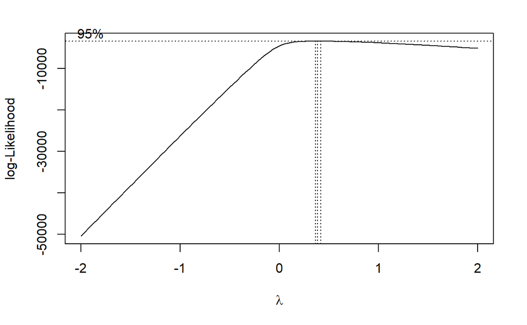

```r
#Case 3

#Refit with transformation due to negative value existing in boxcox
melter.boot.refit.3 <- lm(viscosity+1e-10~voltage + ind2 + temp2
                          + temp4 + temp5 + temp6 + temp7 + temp8
                          + temp9 +temp12 + temp14
                        , data=melter)

require(MASS)
boxcox(melter.boot.refit.3)
```

```r
NA
NA
NA
```

```r
# refit with lambda
melter.boot.refit.3 <- lm((viscosity+1e-10)^(0.4)~voltage + ind2 + temp2
                          + temp4 + temp5 + temp6 + temp7 + temp8
                          + temp9 +temp12 + temp14
                        , data=melter)

summary(melter.boot.refit.3)
```

```
Call:
lm(formula = (viscosity + 1e-10)^(0.4) ~ voltage + ind2 + temp2 +
    temp4 + temp5 + temp6 + temp7 + temp8 + temp9 + temp12 +
    temp14, data = melter)

Residuals:
     Min       1Q   Median       3Q      Max
-11.1366  -1.0418   0.6226   1.9299  10.2596

Coefficients:
              Estimate Std. Error t value Pr(>|t|)
(Intercept)  6.8330334  8.7743744   0.779 0.436335
voltage      0.0026988  0.0020333   1.327 0.184758
ind2         0.0945807  0.0345777   2.735 0.006356 **
temp2       -0.0428914  0.0130466  -3.288 0.001050 **
temp4       -0.0131844  0.0077036  -1.711 0.087346 .
temp5       -0.0102153  0.0049942  -2.045 0.041107 *
temp6        0.0238647  0.0094484   2.526 0.011717 *
temp7        0.0003946  0.0107383   0.037 0.970694
temp8        0.0471720  0.0140629   3.354 0.000829 ***
temp9       -0.0315841  0.0098043  -3.221 0.001322 **
temp12       0.0084452  0.0109498   0.771 0.440756
temp14       0.0147122  0.0140316   1.049 0.294690
---
Signif. codes:  0 ‘***’ 0.001 ‘**’ 0.01 ‘*’ 0.05 ‘.’ 0.1 ‘ ’ 1

Residual standard error: 3.382 on 888 degrees of freedom
Multiple R-squared:  0.1951,    Adjusted R-squared:  0.1851
F-statistic: 19.57 on 11 and 888 DF,  p-value: < 2.2e-16
```

```r
melter.boot.refit.sd.3 <- coef(summary(melter.boot.refit.3))[, "Std. Error"][2:12]


#comparison with barplot
par(mfrow=c(1,2))
barplot(melter.boot.refit.sd, las=2
        , main = "Standard error without extension"
        , ylab = "stnadard error"
        , xlab = "variables"
        , cex.lab = 0.7
        , cex.main=0.7)
barplot(melter.boot.refit.sd.3, las=2
        ,  main = "Standard error with extension (3)"
        , ylab = "stnadard error"
        , xlab = "variables"
        , cex.lab = 0.7
        , cex.main=0.7)
```

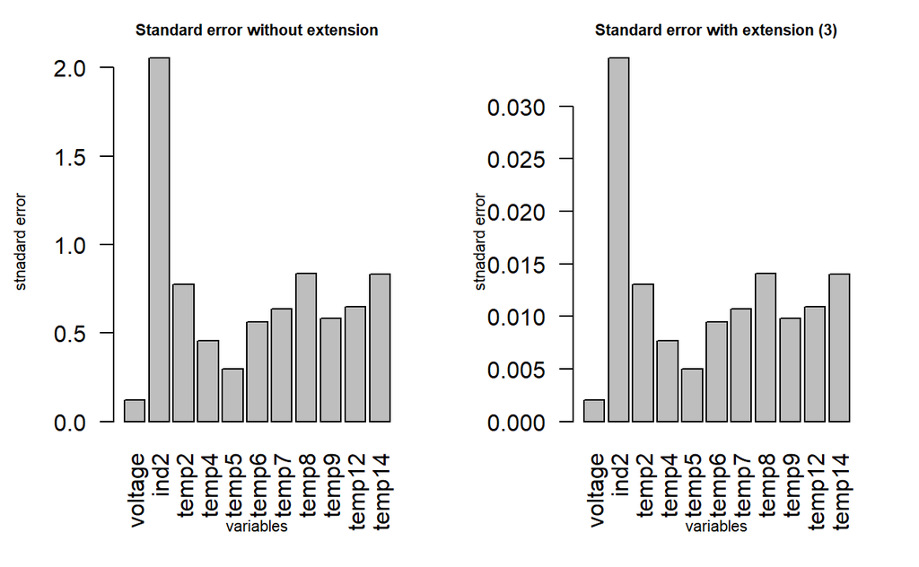

```r
#comparison with residual plot
par(mfrow=c(2,2), cex=0.4)
```

```r
plot(melter.boot.refit$residuals
     ,main = "residual plot without extension")
plot(melter.boot.refit$fitted, melter.boot.refit$residuals
     , main = "residual against fitted value without extension")
```

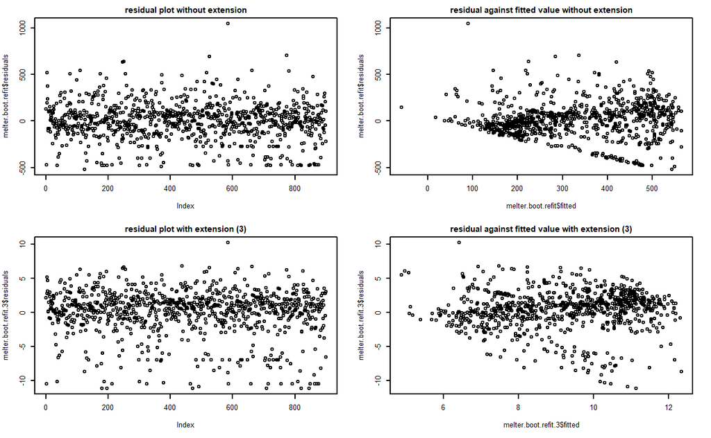

```r
plot(melter.boot.refit.3$residuals
     ,main = "residual plot with extension (3)")
plot(melter.boot.refit.3$fitted, melter.boot.refit.3$residuals
     ,main = "residual against fitted value with extension (3)")
```

Since there are negative value existing in the fitted value, boxcox transformation should be done with modification to avoid calculation error for the $\lambda$ detection in boxcox.

Modified boxcox transformation:

[figure not shown]

where $\lambda_2$ is constant to eliminate the negative value for fitted value. $y$ is the response variable .

Comparing to Task 5, the coefficient of determination($R^2$) drops significantly from 0.3 to 0.19 for the extension 3.

Therefore, transformation of response variable with boxcox can reduce the standard error and lessen the heteroscedasticity. However, in return, it greatly reduced the coefficient of determination ($R^2$).